# Main Analyses

2025-06-16

This document contains all of the main analyses to report for the actor-partner interdependence models for Aims 1-3. Load packages we’ll need:

```r
library(tidyverse)
library(sjmisc)
library(psych)
library(brms)
library(cmdstanr)
# set options for brms to utilized cmdstanr rather than rstan default
options(mc.cores = 4,
        brms.backend = "cmdstanr")
library(simstudy)
library(marginaleffects)
library(tidybayes)
library(easystats)
```

Set options for Load the dataframe that we’ll use for these analyses (created from data_clean_prep file).

```r
data_clean <- readRDS("data/CCS_data_cleaned.rds")
```

# Prep for analyses

Let’s clean up the dataframe so we only have the summary variables and relevant covariates - we don’t need item level data for the main analyses here.

```r
data <- data_clean |>
  select(CoupleID, ParticipantID,
         # main variables
         IHS_mean, PANAS_disc_neg, PANAS_life_neg, CTS_phys_perp_HR, CTS_psych_perp_HR, CTS_psych_perp_HR_minor, CTS_psych_perp_HR_severe, CTS_sgm_perp_HR,
         # covariates
         Age, rel_length_yrs, sxlorx_dich, gender_three, race_dich,
         CSI_sum, DiscussionOrder,
         GlobalCoping_rc_disc, stressor_type_rc_disc, DiscrimTopic_sev, DiscrimTopic_choice,
         GlobalCoping_rc_life, stressor_type_rc_life, StressorTopic_sev, StressorTopic_choice,
         starts_with("missing"))
glimpse(data)
```

```
## Rows: 168
## Columns: 36
## $ CoupleID                 <dbl> 1001, 1001, 1002, 1002, 1006, 1006, 1007, 100…
## $ ParticipantID            <dbl> 101, 102, 103, 104, 111, 112, 113, 114, 117, …
## $ IHS_mean                 <dbl> 1.444444, 1.222222, 1.666667, 1.666667, 1.000…
## $ PANAS_disc_neg           <dbl> 12, 13, 12, 11, 13, 15, 10, 12, 11, 14, 17, 1…
## $ PANAS_life_neg           <dbl> 12, 15, 13, 13, 13, 16, 10, 11, 12, 10, 17, 1…
## $ CTS_phys_perp_HR         <dbl> 0, 0, 0, 0, 0, 0, 0, 0, 0, 0, 0, 0, 0, 0, 0, …
## $ CTS_psych_perp_HR        <dbl> 5, 6, 22, 22, 2, 2, 1, 4, 12, 8, 4, 2, 3, 6, …
## $ CTS_psych_perp_HR_minor  <dbl> 5, 6, 14, 7, 2, 2, 1, 4, 12, 6, 4, 2, 3, 6, 3…
## $ CTS_psych_perp_HR_severe <dbl> 0, 0, 8, 15, 0, 0, 0, 0, 0, 2, 0, 0, 0, 0, 5,…
## $ CTS_sgm_perp_HR          <dbl> 0, 0, 0, 0, 0, 0, 0, 0, 0, 0, 0, 0, 0, 0, 0, …
## $ Age                      <dbl> 25, 25, 30, 29, 21, 21, 24, 25, 20, 26, 21, 2…
## $ rel_length_yrs           <dbl> 0.9166667, 0.9166667, 6.0000000, 6.0000000, 2…
## $ sxlorx_dich              <fct> Bi+, Bi+, Bi+, Bi+, Bi+, Bi+, Bi+, Bi+, Bi+, …
```

[output cut: 23 more lines]

Need to make IHS and PANAS into actor & partner effects. We’re going to pull a function created based on Kenny et al.’s (2006) Doing Dyadic Data Analyses book.

```r
long_to_pw <- function(df, dyadid, var){
  df %>%
    group_by({{dyadid}}) %>%
    mutate("{{var}}_partner" := coalesce(lead({{var}}), lag({{var}}))) %>%
    ungroup() %>%
    rename("{{var}}_actor" := {{var}}) %>%
    relocate(ends_with("_partner"), .after = ends_with("_actor"))
}
data <- long_to_pw(data, CoupleID, IHS_mean)
data <- long_to_pw(data, CoupleID, PANAS_disc_neg)
data <- long_to_pw(data, CoupleID, PANAS_life_neg)
glimpse(data)
```

```
## Rows: 168
## Columns: 39
## $ CoupleID                 <dbl> 1001, 1001, 1002, 1002, 1006, 1006, 1007, 100…
## $ ParticipantID            <dbl> 101, 102, 103, 104, 111, 112, 113, 114, 117, …
## $ IHS_mean_actor           <dbl> 1.444444, 1.222222, 1.666667, 1.666667, 1.000…
## $ PANAS_disc_neg_actor     <dbl> 12, 13, 12, 11, 13, 15, 10, 12, 11, 14, 17, 1…
## $ PANAS_life_neg_actor     <dbl> 12, 15, 13, 13, 13, 16, 10, 11, 12, 10, 17, 1…
## $ IHS_mean_partner         <dbl> 1.222222, 1.444444, 1.666667, 1.666667, 1.222…
## $ PANAS_disc_neg_partner   <dbl> 13, 12, 11, 12, 15, 13, 12, 10, 14, 11, 13, 1…
## $ PANAS_life_neg_partner   <dbl> 15, 12, 13, 13, 16, 13, 11, 10, 10, 12, 13, 1…
## $ CTS_phys_perp_HR         <dbl> 0, 0, 0, 0, 0, 0, 0, 0, 0, 0, 0, 0, 0, 0, 0, …
## $ CTS_psych_perp_HR        <dbl> 5, 6, 22, 22, 2, 2, 1, 4, 12, 8, 4, 2, 3, 6, …
## $ CTS_psych_perp_HR_minor  <dbl> 5, 6, 14, 7, 2, 2, 1, 4, 12, 6, 4, 2, 3, 6, 3…
## $ CTS_psych_perp_HR_severe <dbl> 0, 0, 8, 15, 0, 0, 0, 0, 0, 2, 0, 0, 0, 0, 5,…
## $ CTS_sgm_perp_HR          <dbl> 0, 0, 0, 0, 0, 0, 0, 0, 0, 0, 0, 0, 0, 0, 0, …
```

[output cut: 26 more lines]

Go ahead and standardize or grand-mean center continuous predictors.

```r
center <- function(x){
  (x - mean(x, na.rm = T))
}
std <- function(x){
  (x - mean(x, na.rm = T)) / sd(x, na.rm = T)
}
data <- data |>
  mutate(across(c(GlobalCoping_rc_disc, GlobalCoping_rc_life, DiscrimTopic_sev, StressorTopic_sev), center)) |>
  mutate(across(c(Age, rel_length_yrs, CSI_sum, IHS_mean_actor, IHS_mean_partner, PANAS_disc_neg_actor, PANAS_life_neg_actor, PANAS_disc_neg_partner, PANAS_life_neg_partner), std))
```

I made the decision to standardize most variables for ease of interpretation and to keep model estimation simpler - it is possible to have sampling issues if you have many variables with wildly different scales.

Create a binary outcome variable for physical and SGM-specific IPV:

```r
data <- data |>
  mutate(CTS_phys_perp_binary = if_else(CTS_phys_perp_HR > 0, 1, 0),
         CTS_sgm_perp_binary = if_else(CTS_sgm_perp_HR > 0, 1, 0)) |>
  relocate(c(CTS_phys_perp_binary, CTS_sgm_perp_binary), .after = CTS_sgm_perp_HR)
```

# Model likelihood

Before we start on any of the main analyses, we need to properly specify the likelihood to be used in `brms()` models. We’ll be utilizing a hurdle model approach, which models both the occurrence and the frequency of IPV perpetration. The occurrence is modeled as a logistic regression (0/1 did it happen or not). Frequency is modeled among those who had 1s (happened) and can be specified in as a Poisson or negative binomial distribution. Typically, we justify Poisson vs. negative binomial by looking at the mean & variance of the outcome variable. Poisson is only appropriate when the mean and variance are roughly equal. This is *not* the case for pretty much all of the variables (see output from analyses_basic.Rmd files), so we’ll go for the negative binomial distribution in these analyses. Before we get into any more complex model building, let’s go ahead and run an outcomes-only model for each type of IPV so we can see what that looks like and to build up some of the interpretation here. We’ll do so using default priors in `brms()` . Reported analyses will utilize informative priors based on prior work (see below).

For future reference, here are more resources on the hurdle modeling approach that were consulted in this: - https://www.andrewheiss.com/blog/2022/05/09/hurdle-lognormal-gaussian-brms/ - For hurdle distribution functions: https://rdrr.io/cran/brms/man/Hurdle.html - Marginal effects package page that has material on processing stuff: https://vincentarelbundock.github.io/marginaleffects/articles/comparisons.html#ratios

## Priors

### Default

Ok so let’s take a look at what these models look like with default priors here. We’ll split this up by psychological and then physical & SGM-specific IPV perpetration b/c there are vastly different rates of zeroes across these two variables. For psych (minor + overall), almost everyone perpetrated a little bit wheres for physical and SGM-specific, only ~15% of the sample had endorsed any perpetration in the past year. Let’s run these models:

```r
like_psych <- brm(bf(CTS_psych_perp_HR ~ 1,
                     hu ~ 1),
                  data = data,
                  family = hurdle_negbinomial(),
                  chains = 4, iter = 2000, warmup = 1000, cores = 4,
                  seed = 1234,
                  file = "fits/like_psych",
                  file_refit = "on_change"
                  )
like_psych_min <- brm(bf(CTS_psych_perp_HR_minor ~ 1,
                     hu ~ 1),
                  data = data,
                  family = hurdle_negbinomial(),
                  chains = 4, iter = 2000, warmup = 1000, cores = 4,
                  seed = 1234,
                  file = "fits/like_psych_min",
                  file_refit = "on_change"
                  )

like_psych_sev <- brm(bf(CTS_psych_perp_HR_severe ~ 1,
                     hu ~ 1),
                  data = data,
                  family = hurdle_negbinomial(),
                  chains = 4, iter = 2000, warmup = 1000, cores = 4,
                  seed = 1234,
                  file = "fits/like_psych_sev",
                  file_refit = "on_change"
                  )
like_phys <- brm(bf(CTS_phys_perp_HR ~ 1,
                     hu ~ 1),
                  data = data,
                  family = hurdle_negbinomial(),
                  chains = 4, iter = 2000, warmup = 1000, cores = 4,
                  seed = 1234,
                  file = "fits/like_phys",
                  file_refit = "on_change"
                  )
like_sgm <- brm(bf(CTS_sgm_perp_HR ~ 1,
                   hu ~ 1),
                  data = data,
                  family = hurdle_negbinomial(),
                  chains = 4, iter = 2000, warmup = 1000, cores = 4,
                  seed = 1234,
                  file = "fits/like_sgm",
                  file_refit = "on_change"
                  )
```

Let’s take a look at psych IPV perpetration first. Let’s go ahead and summarize that model here:

```r
summary(like_psych)
```

[output not shown]

[output not shown]

[output not shown]

```
##  Family: hurdle_negbinomial
##   Links: mu = log; shape = identity; hu = logit
## Formula: CTS_psych_perp_HR ~ 1
##          hu ~ 1
##    Data: data (Number of observations: 164)
##   Draws: 4 chains, each with iter = 2000; warmup = 1000; thin = 1;
##          total post-warmup draws = 4000
##
## Regression Coefficients:
##              Estimate Est.Error l-95% CI u-95% CI Rhat Bulk_ESS Tail_ESS
## Intercept        2.95      0.15     2.63     3.21 1.00     2202     2071
## hu_Intercept    -2.34      0.27    -2.87    -1.83 1.00     2883     2311
##
## Further Distributional Parameters:
##       Estimate Est.Error l-95% CI u-95% CI Rhat Bulk_ESS Tail_ESS
## shape     0.44      0.10     0.26     0.64 1.00     2378     2057
##
## Draws were sampled using sample(hmc). For each parameter, Bulk_ESS
## and Tail_ESS are effective sample size measures, and Rhat is the potential
## scale reduction factor on split chains (at convergence, Rhat = 1).
```

The Intercept population-level effect here is the negative binomial term. This is in the log scale, which needs to be exponentiated for interpretation. In the above model, the Intercept term is 2.94. That would correspond to:

```r
exp(2.94)
```

```
## [1] 18.91585
```

This is the “rate” for the Poisson distribution, which is just the mean & is also called lambda. The shape parameter basically describes the Poisson rates across each of the cases b/c we have parameterized this model to allow for each case to have it’s own rate to account for over-dispersion. This is not directly interpreted. hu_Intercept term is the proportion of zeros in the data. This is in the logit scale, which needs to be back-transformed for interpretation. In the above model, the hu_Intercept term is -2.33. That would correspond to:

```r
inv_logit_scaled(-2.33)
```

```
## [1] 0.08866866
```

Let’s see how that works out for minor and severe psych IPV perpetration.

```r
summary(like_psych_min)
```

```
##  Family: hurdle_negbinomial
##   Links: mu = log; shape = identity; hu = logit
## Formula: CTS_psych_perp_HR_minor ~ 1
##          hu ~ 1
##    Data: data (Number of observations: 168)
##   Draws: 4 chains, each with iter = 2000; warmup = 1000; thin = 1;
##          total post-warmup draws = 4000
##
## Regression Coefficients:
##              Estimate Est.Error l-95% CI u-95% CI Rhat Bulk_ESS Tail_ESS
## Intercept        2.76      0.14     2.45     3.01 1.00     1919     1421
## hu_Intercept    -2.15      0.24    -2.64    -1.70 1.00     3185     2479
##
## Further Distributional Parameters:
##       Estimate Est.Error l-95% CI u-95% CI Rhat Bulk_ESS Tail_ESS
## shape     0.50      0.11     0.28     0.74 1.00     1945     1547
##
## Draws were sampled using sample(hmc). For each parameter, Bulk_ESS
## and Tail_ESS are effective sample size measures, and Rhat is the potential
## scale reduction factor on split chains (at convergence, Rhat = 1).
```

```r
exp(2.76)
```

```
## [1] 15.79984
```

```r
inv_logit_scaled(-2.15)
```

```
## [1] 0.1043312
```

```r
summary(like_psych_sev)
```

```
##  Family: hurdle_negbinomial
##   Links: mu = log; shape = identity; hu = logit
## Formula: CTS_psych_perp_HR_severe ~ 1
##          hu ~ 1
##    Data: data (Number of observations: 164)
##   Draws: 4 chains, each with iter = 2000; warmup = 1000; thin = 1;
##          total post-warmup draws = 4000
##
## Regression Coefficients:
##              Estimate Est.Error l-95% CI u-95% CI Rhat Bulk_ESS Tail_ESS
## Intercept       -2.22      3.42   -10.27     1.77 1.01      553      552
## hu_Intercept     0.20      0.16    -0.11     0.51 1.00     1150     1323
##
## Further Distributional Parameters:
##       Estimate Est.Error l-95% CI u-95% CI Rhat Bulk_ESS Tail_ESS
## shape     0.05      0.10     0.00     0.35 1.01      556      556
##
## Draws were sampled using sample(hmc). For each parameter, Bulk_ESS
## and Tail_ESS are effective sample size measures, and Rhat is the potential
## scale reduction factor on split chains (at convergence, Rhat = 1).
```

```r
exp(-2.22)
```

```
## [1] 0.1086091
```

```r
inv_logit_scaled(0.20)
```

```
## [1] 0.549834
```

We see here that the minor model was relatively similar to the observed data, but the severe model was less so. The model is widely uncertain about the rate and it does not mirror the observed data.

Now let’s do this for physical:

```r
summary(like_phys)
```

```
##  Family: hurdle_negbinomial
##   Links: mu = log; shape = identity; hu = logit
## Formula: CTS_phys_perp_HR ~ 1
##          hu ~ 1
##    Data: data (Number of observations: 164)
##   Draws: 4 chains, each with iter = 2000; warmup = 1000; thin = 1;
##          total post-warmup draws = 4000
##
## Regression Coefficients:
##              Estimate Est.Error l-95% CI u-95% CI Rhat Bulk_ESS Tail_ESS
## Intercept       -3.25      2.88   -10.78     0.77 1.00      736      477
## hu_Intercept     1.71      0.21     1.29     2.13 1.01     1483     1535
##
## Further Distributional Parameters:
##       Estimate Est.Error l-95% CI u-95% CI Rhat Bulk_ESS Tail_ESS
## shape     0.00      0.01     0.00     0.03 1.00      719      473
##
## Draws were sampled using sample(hmc). For each parameter, Bulk_ESS
## and Tail_ESS are effective sample size measures, and Rhat is the potential
## scale reduction factor on split chains (at convergence, Rhat = 1).
```

Mean/rate:

```r
exp(-3.23)
```

```
## [1] 0.0395575
```

% of 0s:

```r
plogis(1.70)
```

```
## [1] 0.8455347
```

We see here that the proportion of zeroes predicted by the model is pretty close to the observed data (84%) but the mean rate of IPV is VASTLY underestimated relative to the empirical mean here. However, there is a HUGE range of credible values for that mean rate (range from 0 to 2.16, which is closer to the empirial mean at the tail end). What this means is that the model is pretty uncertain about what that rate could be, and this is likely because there is just so little data from which to make this estimation. Further, we have a pretty severe outlier in the couple. For now, we’re going to keep that couple in b/c, as McElreath notes, outliers are sometimes true data to not be discarded. We’ll do some sensitivity analyses later on to see how they influence parameter estimation.

Finally, let’s look at SGM-specific perpetration:

```r
summary(like_sgm)
```

[output not shown]

```
##  Family: hurdle_negbinomial
##   Links: mu = log; shape = identity; hu = logit
## Formula: CTS_sgm_perp_HR ~ 1
##          hu ~ 1
##    Data: data (Number of observations: 164)
##   Draws: 4 chains, each with iter = 2000; warmup = 1000; thin = 1;
##          total post-warmup draws = 4000
##
## Regression Coefficients:
##              Estimate Est.Error l-95% CI u-95% CI Rhat Bulk_ESS Tail_ESS
## Intercept       -2.47      2.92    -9.41     1.32 1.00      915      794
## hu_Intercept     1.84      0.22     1.43     2.29 1.00     1606     1467
##
## Further Distributional Parameters:
##       Estimate Est.Error l-95% CI u-95% CI Rhat Bulk_ESS Tail_ESS
## shape     0.10      0.24     0.00     0.84 1.00      910      767
##
## Draws were sampled using sample(hmc). For each parameter, Bulk_ESS
## and Tail_ESS are effective sample size measures, and Rhat is the potential
## scale reduction factor on split chains (at convergence, Rhat = 1).
```

Mean rate:

```r
exp(-2.47)
```

```
## [1] 0.08458486
```

% of 0s:

```r
plogis(1.84)
```

```
## [1] 0.8629487
```

Again, we see that the prediction of zeroes is pretty close to the empirical data but the overall mean is pretty under-estimated relative to the empirical means.

OK. SO. The default priors are bad. We know that they are going to have a minimal influence on the parameter estimates and so they’re going to rely on the data more for estimating the posterior. This is probably fine for overall and minor psychological IPV b/c we have a good amount of data there, but this is definitely not fine for physical and SGM-specific IPV because of the low rates of perpetration. It might not be fine for severe psychological IPV either. And, regardless, we can do better b/c we have content domain knowledge about what are reasonable bounds of the data for these models.

One question I have is how the hurdle model works with simulated data, so I can see whether the model actually picks up on the population parameters that we used. It’s real possible that these models get finicky with the physical and SGM-specific IPV perpetration estimates b/c there is so little data. In this next section, I play around with priors for these models.

### Simulating hurdle models

#### Physical & SGM-specific IPV

First, let’s see what the default priors are for these models:

```r
prior_summary(like_phys)
```

```
##                    prior     class coef group resp dpar nlpar lb ub  source
##  student_t(3, -2.3, 2.5) Intercept                                  default
##           logistic(0, 1) Intercept                   hu             default
##        gamma(0.01, 0.01)     shape                             0    default
```

This are pretty broad, and will allow the data to have free reign on the posterior. Let’s simulate some data from the `simstudy` package.

First, simulate some data:

```r
# set population parameters - formula is the Intercept rate and the variance is the dispersion parameter
def <- defData(varname = "ipv", dist = "negBinomial", formula = 1, variance = 15, link = "log")

# simulate a dataset of 184 people to utilize
set.seed(12345)
dd <- genData(168, def)
```

Let’s see what that looks like

```r
dd |> frq(ipv)
```

```
## ipv <integer>
## # total N=168 valid N=168 mean=4.10 sd=14.28
##
## Value |   N | Raw % | Valid % | Cum. %
## --------------------------------------
##     0 | 132 | 78.57 |   78.57 |  78.57
##     1 |   5 |  2.98 |    2.98 |  81.55
##     2 |   3 |  1.79 |    1.79 |  83.33
##     3 |   4 |  2.38 |    2.38 |  85.71
##     4 |   2 |  1.19 |    1.19 |  86.90
##     5 |   2 |  1.19 |    1.19 |  88.10
##     6 |   1 |  0.60 |    0.60 |  88.69
##     7 |   1 |  0.60 |    0.60 |  89.29
##     8 |   1 |  0.60 |    0.60 |  89.88
##    10 |   2 |  1.19 |    1.19 |  91.07
##    12 |   1 |  0.60 |    0.60 |  91.67
##    15 |   2 |  1.19 |    1.19 |  92.86
##    16 |   1 |  0.60 |    0.60 |  93.45
##    19 |   1 |  0.60 |    0.60 |  94.05
##    20 |   1 |  0.60 |    0.60 |  94.64
##    27 |   1 |  0.60 |    0.60 |  95.24
##    29 |   1 |  0.60 |    0.60 |  95.83
##    30 |   1 |  0.60 |    0.60 |  96.43
##    40 |   1 |  0.60 |    0.60 |  97.02
##    53 |   1 |  0.60 |    0.60 |  97.62
##    73 |   1 |  0.60 |    0.60 |  98.21
##    78 |   2 |  1.19 |    1.19 |  99.40
##   102 |   1 |  0.60 |    0.60 | 100.00
##  <NA> |   0 |  0.00 |    <NA> |   <NA>
```

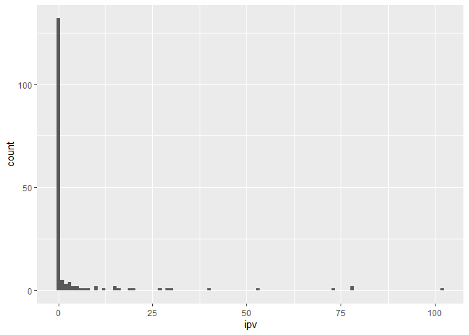

```r
ggplot(dd, aes(x = ipv)) + geom_histogram(binwidth = 1)
```

Now, let’s go ahead and run the model:

```r
sim_phys_1 <- brm(bf(ipv ~ 1,
                     hu ~ 1),
                     data = dd,
                     family = hurdle_negbinomial(),
                     chains = 4, iter = 2000, warmup = 1000, cores = 4,
                     seed = 1234,
                     file = "fits/sim_phys_1",
                     file_refit = "on_change"
                )
```

And summarize the output:

```r
summary(sim_phys_1)
```

```
##  Family: hurdle_negbinomial
##   Links: mu = log; shape = identity; hu = logit
## Formula: ipv ~ 1
##          hu ~ 1
##    Data: dd (Number of observations: 168)
##   Draws: 4 chains, each with iter = 2000; warmup = 1000; thin = 1;
##          total post-warmup draws = 4000
##
## Regression Coefficients:
##              Estimate Est.Error l-95% CI u-95% CI Rhat Bulk_ESS Tail_ESS
## Intercept       -2.24      3.17    -9.57     2.66 1.00      673      697
## hu_Intercept     1.28      0.18     0.93     1.64 1.00     1511     1585
##
## Further Distributional Parameters:
##       Estimate Est.Error l-95% CI u-95% CI Rhat Bulk_ESS Tail_ESS
## shape     0.03      0.08     0.00     0.30 1.00      671      729
##
## Draws were sampled using sample(hmc). For each parameter, Bulk_ESS
## and Tail_ESS are effective sample size measures, and Rhat is the potential
## scale reduction factor on split chains (at convergence, Rhat = 1).
```

Let’s also do a posterior predictive check to see how well the model-implied predicted values correspond to the actual data.

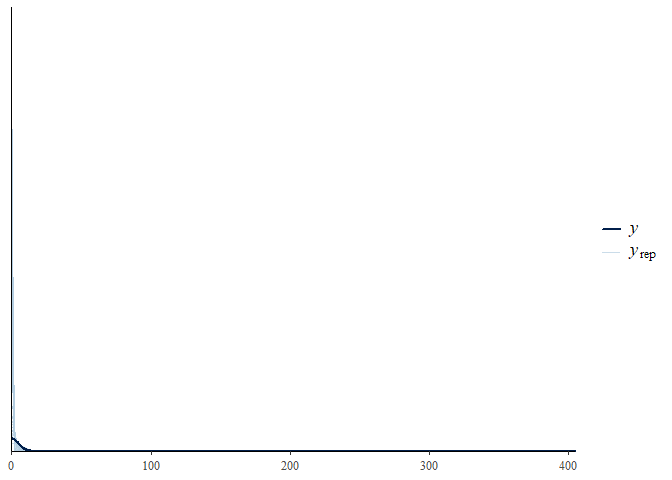

```r
pp_check(sim_phys_1, ndraws = 100)
```

Not the worst in the world, but it’s not doing a particularly good job here either.

Let’s take a look at what some more sensible priors would look like. Note, for documentation here I just have the ones that I landed on but different values can be played around with if needed.

```r
# a is the Intercept term ON THE LOG SCALE, b is the hu_Intercept term ON THE LOG ODDS/LOGIT SCALE; we then back-transform to see what these priors imply about the observed data
set.seed(1234)
psim <- tibble(a = rnorm(1e4, mean = 0, sd = 0.8),
               b = rnorm(1e4, mean = 1.5, sd = 1)) |>
  mutate(lambda = exp(a),
         hu = inv_logit_scaled(b))
```

Let’s take a look at the Intercept term (expected mean/rate)

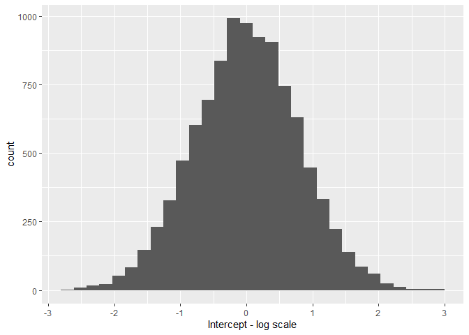

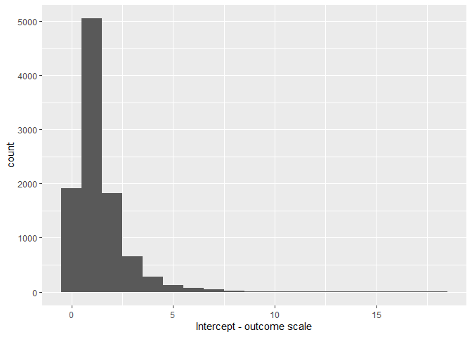

```r
ggplot(psim, aes(x = a)) + geom_histogram() + xlab("Intercept - log scale")
ggplot(psim, aes(x = lambda)) + geom_histogram(binwidth = 1) + xlab("Intercept - outcome scale")
```

And the hu_Intercept term (proportion of 0s in the data)

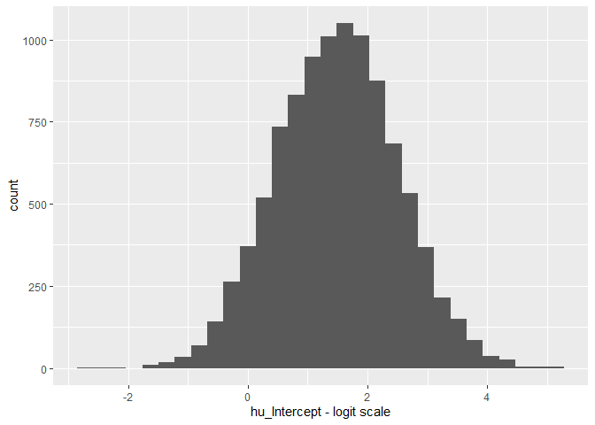

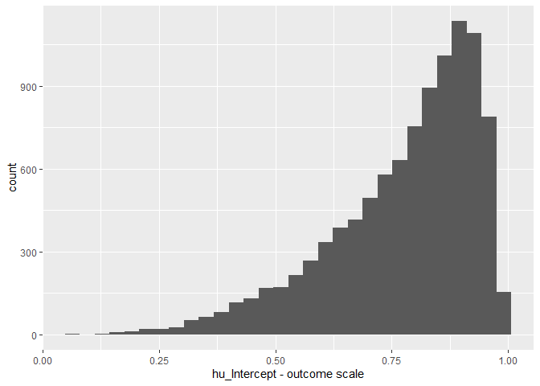

```r
ggplot(psim, aes(x = b)) + geom_histogram() + xlab("hu_Intercept - logit scale")
ggplot(psim, aes(x = hu)) + geom_histogram() + xlab("hu_Intercept - outcome scale")
```

Finally, we have the shape parameter that we want to think about. First let’s simulate that default prior:

```r
set.seed(1234)
psim <- psim |>
  mutate(c = rgamma(1e4, 0.01, 0.01))
```

Then plot it:

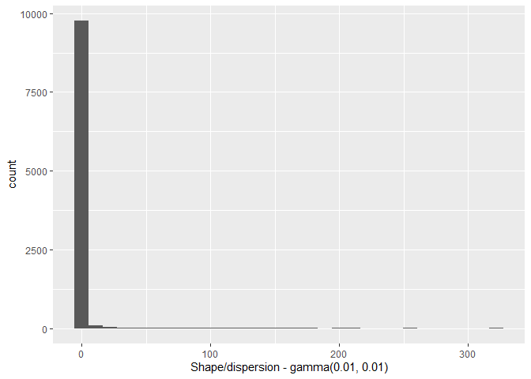

```r
ggplot(psim, aes(x = c)) + geom_histogram() + xlab("Shape/dispersion - gamma(0.01, 0.01)")
```

We see here that there are plausible values that go into the 100s. Note that this is on the scale of the data, although it’s a little weird to interpret the parameter directly. That’s pretty wild, let’s keep it at a more reasonable level with the weakly regularizing exponential(1) prior:

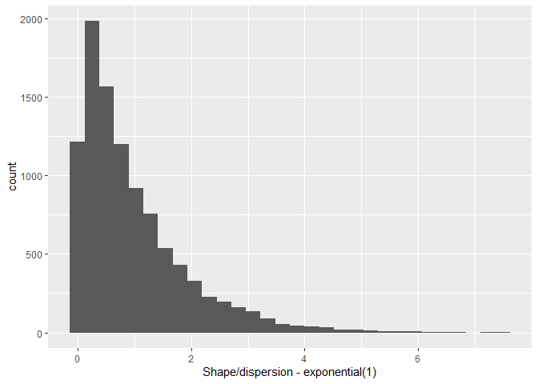

```r
set.seed(1234)
psim <- psim |>
  mutate(c = rexp(1e4, 1))
ggplot(psim, aes(x = c)) + geom_histogram() + xlab("Shape/dispersion - exponential(1)")
```

That’s much more reasonable here. Wonderful!

Great, those all look pretty reasonable in terms of the mean/rate & the probability of being a 0 & the dispersion. Let’s go ahead and re-run the model with these priors. We’ll also place a more regularized prior on the dispersion parameter (labeled shape) so it’s not going to go off into the wild too much.

```r
sim_phys_2 <- brm(bf(ipv ~ 1,
                     hu ~ 1),
                  prior = c(prior(normal(0, 0.8), class = Intercept), # prior on mean (log scale)
                            prior(normal(1.5, 1), class = Intercept, dpar = hu), # prior on odds of being 0 (logit scale)
                            prior(exponential(1), class = shape) # prior on dispersion
                  ),
                     data = dd,
                     family = hurdle_negbinomial(),
                     chains = 4, iter = 2000, warmup = 1000, cores = 4,
                     seed = 1234,
                     file = "fits/sim_phys_2",
                     file_refit = "on_change"
                )
```

And summarize the output:

```r
summary(sim_phys_2)
```

```
##  Family: hurdle_negbinomial
##   Links: mu = log; shape = identity; hu = logit
## Formula: ipv ~ 1
##          hu ~ 1
##    Data: dd (Number of observations: 168)
##   Draws: 4 chains, each with iter = 2000; warmup = 1000; thin = 1;
##          total post-warmup draws = 4000
##
## Regression Coefficients:
##              Estimate Est.Error l-95% CI u-95% CI Rhat Bulk_ESS Tail_ESS
## Intercept        0.89      0.85    -0.81     2.40 1.00     1342     1618
## hu_Intercept     1.32      0.19     0.95     1.71 1.00     1985     1615
##
## Further Distributional Parameters:
##       Estimate Est.Error l-95% CI u-95% CI Rhat Bulk_ESS Tail_ESS
## shape     0.06      0.07     0.00     0.27 1.00     1311     1650
##
## Draws were sampled using sample(hmc). For each parameter, Bulk_ESS
## and Tail_ESS are effective sample size measures, and Rhat is the potential
## scale reduction factor on split chains (at convergence, Rhat = 1).
```

Now this is MUCH better - we see that the Intercept is roughly within the range of the population parameter. Further, we see that the compatibility interval around that estimate now contains the true population parameter (1.0), which is much more encouraging. These priors still leave some room for the data to speak to the story of what is going on here.

Finally, let’s take a look at the posterior predictive check:

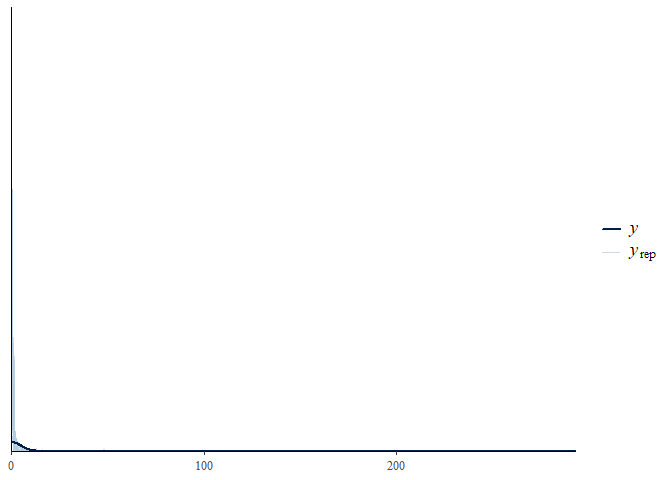

```r
pp_check(sim_phys_2, ndraws = 100)
```

That’s roughly within the bounds of the simulated data as well, although the model does predict some potential really extreme values out in the tails. That’s ok - that is possible in these data where you might get a really aggressive couple or two in the sample.

#### Psych IPV - overall & minor

Now let’s fiddle with some data simulation where the rate of zeroes in psych IPV (both overall and minor) is closer to 10% (vs. 80ish% for physical & SGM-specific IPV).

First, simulate some data:

```r
# set population parameters - formula is the Intercept rate and the variance is the dispersion parameter
def <- defData(varname = "ipv", dist = "negBinomial", formula = 3, variance = 2, link = "log")

# simulate a dataset of 184 people to utilize
set.seed(12345)
dd <- genData(168, def)
```

Let’s see what that looks like

```r
dd |> frq(ipv)
```

```
## ipv <integer>
## # total N=168 valid N=168 mean=21.00 sd=27.23
##
## Value |  N | Raw % | Valid % | Cum. %
## -------------------------------------
##     0 | 21 | 12.50 |   12.50 |  12.50
##     1 | 10 |  5.95 |    5.95 |  18.45
##     2 |  9 |  5.36 |    5.36 |  23.81
##     3 |  6 |  3.57 |    3.57 |  27.38
##     4 | 11 |  6.55 |    6.55 |  33.93
##     5 |  5 |  2.98 |    2.98 |  36.90
##     6 |  5 |  2.98 |    2.98 |  39.88
##     7 |  4 |  2.38 |    2.38 |  42.26
##     8 |  3 |  1.79 |    1.79 |  44.05
##     9 |  9 |  5.36 |    5.36 |  49.40
```

[output cut: 47 more lines]

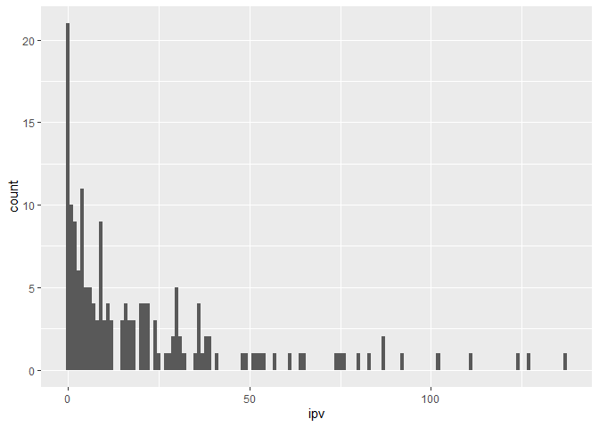

```r
ggplot(dd, aes(x = ipv)) + geom_histogram(binwidth = 1)
```

Now, let’s go ahead and run the model:

```r
sim_psych_1 <- brm(bf(ipv ~ 1,
                     hu ~ 1),
                     data = dd,
                     family = hurdle_negbinomial(),
                     chains = 4, iter = 2000, warmup = 1000, cores = 4,
                     seed = 1234,
                     file = "fits/sim_psych_1",
                     file_refit = "on_change"
                )
```

And summarize the output:

```r
summary(sim_psych_1)
```

```
##  Family: hurdle_negbinomial
##   Links: mu = log; shape = identity; hu = logit
## Formula: ipv ~ 1
##          hu ~ 1
##    Data: dd (Number of observations: 168)
##   Draws: 4 chains, each with iter = 2000; warmup = 1000; thin = 1;
##          total post-warmup draws = 4000
##
## Regression Coefficients:
##              Estimate Est.Error l-95% CI u-95% CI Rhat Bulk_ESS Tail_ESS
## Intercept        3.04      0.12     2.80     3.27 1.00     2562     2584
## hu_Intercept    -1.92      0.23    -2.39    -1.50 1.00     3087     2380
##
## Further Distributional Parameters:
##       Estimate Est.Error l-95% CI u-95% CI Rhat Bulk_ESS Tail_ESS
## shape     0.58      0.11     0.37     0.82 1.00     2460     2480
##
## Draws were sampled using sample(hmc). For each parameter, Bulk_ESS
## and Tail_ESS are effective sample size measures, and Rhat is the potential
## scale reduction factor on split chains (at convergence, Rhat = 1).
```

We see here that, UNLIKE the physical & SGM-specific IPV, the default priors do a much better job in this model. We see parameter estimates that are roughly equivalent to the population parameters that we simulated here. Let’s see how the posterior predictive check fairs:

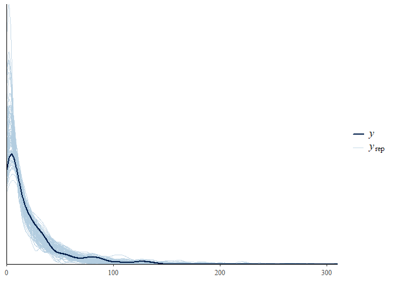

```r
pp_check(sim_psych_1, ndraws = 100)
```

Not too shabby here!

Still, we want to make sure that we have reasoned priors that incorporate our domain knowledge about psych IPV perpetration into the model (rather than just based on the data at hand).

```r
# a is the Intercept term ON THE LOG SCALE, b is the hu_Intercept term ON THE LOG ODDS/LOGIT SCALE; we then back-transform to see what these priors imply about the observed data
set.seed(1234)
psim <- tibble(a = rnorm(1e4, mean = 1, sd = 0.5),
               b = rnorm(1e4, mean = -1.5, sd = 1)) |>
  mutate(lambda = exp(a),
         hu = inv_logit_scaled(b))
```

Let’s take a look at the Intercept term (expected mean/rate)

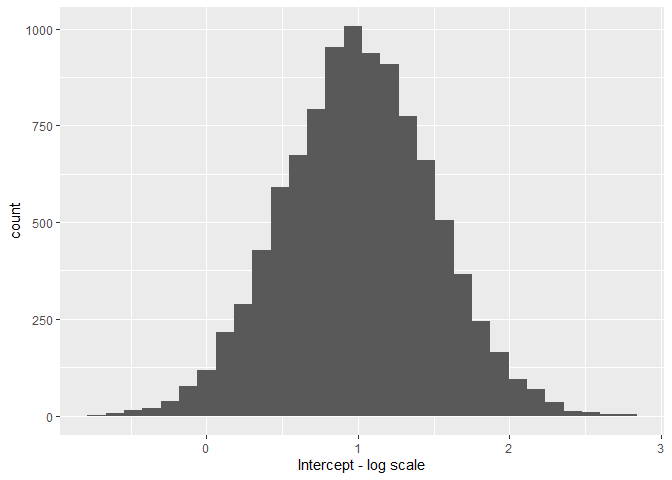

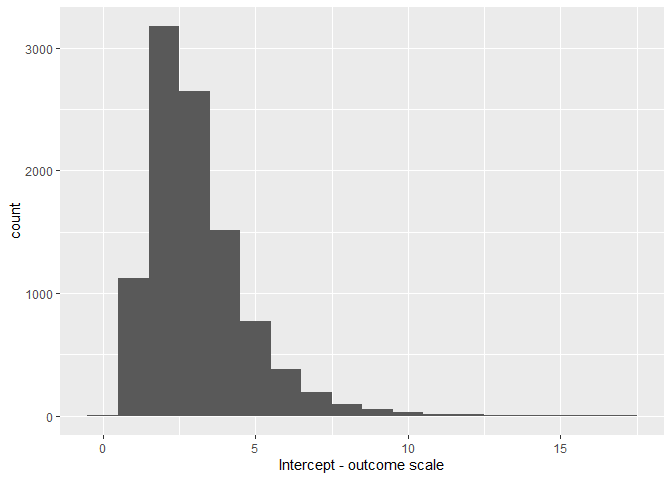

```r
ggplot(psim, aes(x = a)) + geom_histogram() + xlab("Intercept - log scale")
ggplot(psim, aes(x = lambda)) + geom_histogram(binwidth = 1) + xlab("Intercept - outcome scale")
```

And the hu_Intercept term (proportion of 0s in the data)

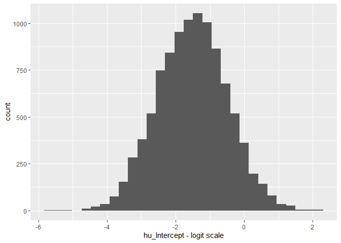

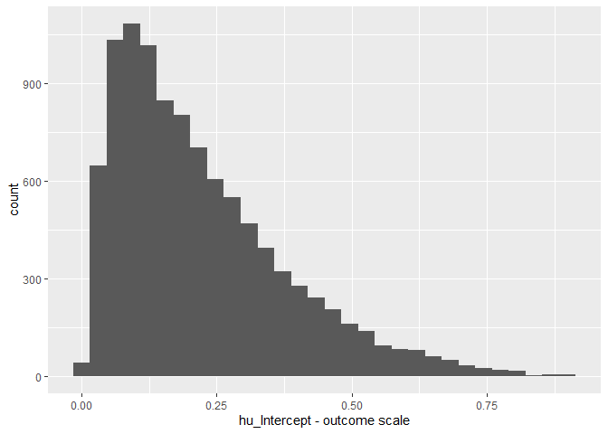

```r
ggplot(psim, aes(x = b)) + geom_histogram() + xlab("hu_Intercept - logit scale")
ggplot(psim, aes(x = hu)) + geom_histogram() + xlab("hu_Intercept - outcome scale")
```

Now let’s re-run the model with those priors:

```r
sim_psych_2 <- brm(bf(ipv ~ 1,
                      hu ~ 1),
                  prior = c(prior(normal(1, 0.5), class = Intercept), # prior on mean (log scale)
                            prior(normal(-1.5, 1), class = Intercept, dpar = hu), # prior on odds of being 0 (logit scale)
                            prior(exponential(1), class = shape) # prior on dispersion
                  ),
                     data = dd,
                     family = hurdle_negbinomial(),
                     chains = 4, iter = 2000, warmup = 1000, cores = 4,
                     seed = 1234,
                     file = "fits/sim_psych_2",
                     file_refit = "on_change"
                )
```

Summarize:

```r
summary(sim_psych_2)
```

```
##  Family: hurdle_negbinomial
##   Links: mu = log; shape = identity; hu = logit
## Formula: ipv ~ 1
##          hu ~ 1
##    Data: dd (Number of observations: 168)
##   Draws: 4 chains, each with iter = 2000; warmup = 1000; thin = 1;
##          total post-warmup draws = 4000
##
## Regression Coefficients:
##              Estimate Est.Error l-95% CI u-95% CI Rhat Bulk_ESS Tail_ESS
## Intercept        2.93      0.13     2.65     3.16 1.00     2226     1572
## hu_Intercept    -1.94      0.23    -2.38    -1.51 1.00     2985     2823
##
## Further Distributional Parameters:
##       Estimate Est.Error l-95% CI u-95% CI Rhat Bulk_ESS Tail_ESS
## shape     0.54      0.12     0.31     0.78 1.00     2230     1932
##
## Draws were sampled using sample(hmc). For each parameter, Bulk_ESS
## and Tail_ESS are effective sample size measures, and Rhat is the potential
## scale reduction factor on split chains (at convergence, Rhat = 1).
```

It’s really not that different from the original, default priors. This is good! It might not matter for this basic, intercept-only model that doesn’t account for nesting but it might in future models as we get more complex here. Let’s check out the posterior predictive check as well:

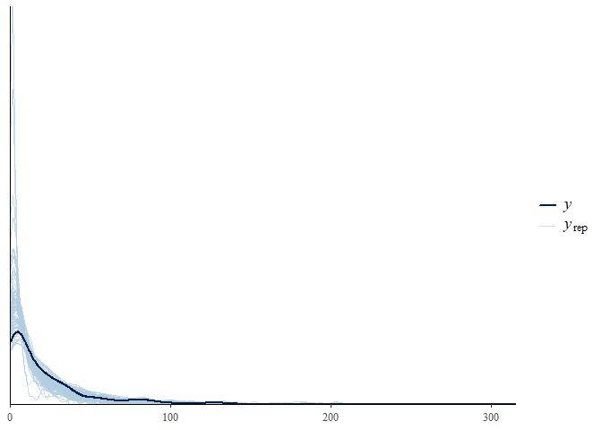

```r
pp_check(sim_psych_2, ndraws = 100)
```

Also doing a really nice job here still!

One thing to note for your future self is that the Intercept parameter in these hurdle models seems to correspond to the OVERALL mean in the data. It’s not necessarily picking up on the mean of those who are > 0.

#### Psych IPV - severe

Now let’s fiddle with some data simulation where the rate of zeroes in severe psych IPV is closer to 50% (vs. 80ish% for physical & SGM-specific IPV + 10% for overall & minor psych IPV).

First, simulate some data:

```r
# set population parameters - formula is the Intercept rate and the variance is the dispersion parameter
def <- defData(varname = "ipv", dist = "negBinomial", formula = 0.5, variance = 3, link = "log")

# simulate a dataset of 184 people to utilize
set.seed(12345)
dd <- genData(168, def)
```

Let’s see what that looks like

```r
dd |> frq(ipv)
```

```
## ipv <integer>
## # total N=168 valid N=168 mean=1.74 sd=2.96
##
## Value |  N | Raw % | Valid % | Cum. %
## -------------------------------------
##     0 | 92 | 54.76 |   54.76 |  54.76
##     1 | 16 |  9.52 |    9.52 |  64.29
##     2 | 19 | 11.31 |   11.31 |  75.60
##     3 | 15 |  8.93 |    8.93 |  84.52
##     4 |  8 |  4.76 |    4.76 |  89.29
##     5 |  2 |  1.19 |    1.19 |  90.48
##     6 |  1 |  0.60 |    0.60 |  91.07
##     7 |  3 |  1.79 |    1.79 |  92.86
##     8 |  3 |  1.79 |    1.79 |  94.64
##     9 |  4 |  2.38 |    2.38 |  97.02
##    10 |  1 |  0.60 |    0.60 |  97.62
##    12 |  1 |  0.60 |    0.60 |  98.21
##    13 |  2 |  1.19 |    1.19 |  99.40
##    17 |  1 |  0.60 |    0.60 | 100.00
##  <NA> |  0 |  0.00 |    <NA> |   <NA>
```

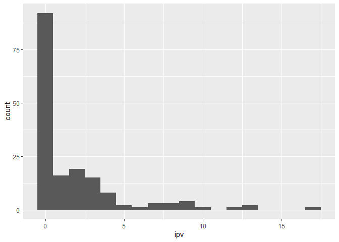

```r
ggplot(dd, aes(x = ipv)) + geom_histogram(binwidth = 1)
```

```r
# a is the Intercept term ON THE LOG SCALE, b is the hu_Intercept term ON THE LOG ODDS/LOGIT SCALE; we then back-transform to see what these priors imply about the observed data
set.seed(1234)
psim <- tibble(a = rnorm(1e4, mean = 1, sd = 0.5),
               b = rnorm(1e4, mean = 0, sd = 0.5)) |>
  mutate(lambda = exp(a),
         hu = inv_logit_scaled(b))
```

Let’s take a look at the Intercept term (expected mean/rate)

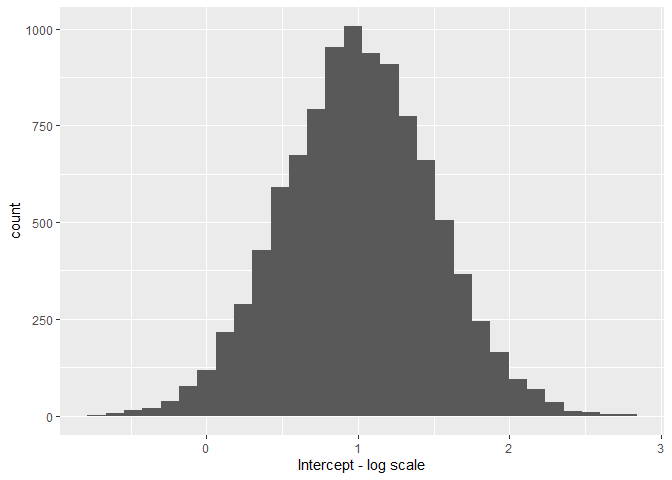

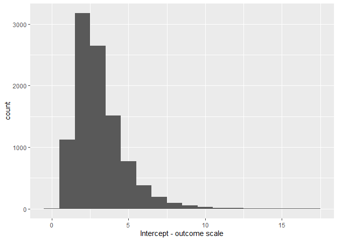

```r
ggplot(psim, aes(x = a)) + geom_histogram() + xlab("Intercept - log scale")
ggplot(psim, aes(x = lambda)) + geom_histogram(binwidth = 1) + xlab("Intercept - outcome scale")
```

And the hu_Intercept term (proportion of 0s in the data)

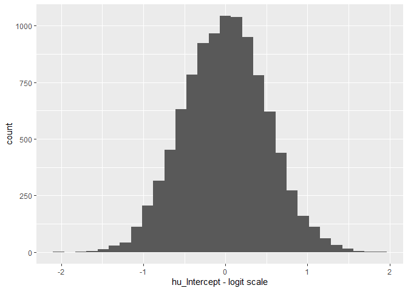

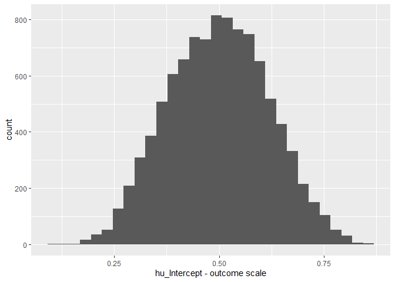

```r
ggplot(psim, aes(x = b)) + geom_histogram() + xlab("hu_Intercept - logit scale")
ggplot(psim, aes(x = hu)) + geom_histogram() + xlab("hu_Intercept - outcome scale")
```

Now let’s re-run the model with those priors:

```r
sim_psych_3 <- brm(bf(ipv ~ 1,
                      hu ~ 1),
                  prior = c(prior(normal(1, 0.5), class = Intercept), # prior on mean (log scale)
                            prior(normal(0, 0.5), class = Intercept, dpar = hu), # prior on odds of being 0 (logit scale)
                            prior(exponential(1), class = shape) # prior on dispersion
                  ),
                     data = dd,
                     family = hurdle_negbinomial(),
                     chains = 4, iter = 2000, warmup = 1000, cores = 4,
                     seed = 1234,
                     file = "fits/sim_psych_3",
                     file_refit = "on_change"
                )
```

Summarize:

```r
summary(sim_psych_3)
```

```
##  Family: hurdle_negbinomial
##   Links: mu = log; shape = identity; hu = logit
## Formula: ipv ~ 1
##          hu ~ 1
##    Data: dd (Number of observations: 168)
##   Draws: 4 chains, each with iter = 2000; warmup = 1000; thin = 1;
##          total post-warmup draws = 4000
##
## Regression Coefficients:
##              Estimate Est.Error l-95% CI u-95% CI Rhat Bulk_ESS Tail_ESS
## Intercept        1.01      0.19     0.59     1.33 1.00     2004     1750
## hu_Intercept     0.17      0.15    -0.12     0.46 1.00     2661     2602
##
## Further Distributional Parameters:
##       Estimate Est.Error l-95% CI u-95% CI Rhat Bulk_ESS Tail_ESS
## shape     1.00      0.42     0.36     2.03 1.00     1837     1764
##
## Draws were sampled using sample(hmc). For each parameter, Bulk_ESS
## and Tail_ESS are effective sample size measures, and Rhat is the potential
## scale reduction factor on split chains (at convergence, Rhat = 1).
```

We see here that it does an OK (but not great) job of capturing the simulated data here.

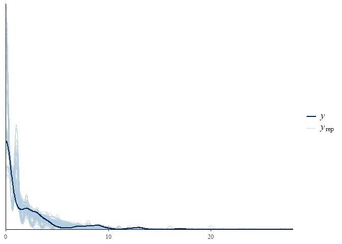

```r
pp_check(sim_psych_3, ndraws = 100)
```

### Informative

Now that we’ve specified some priors, let’s re-run the basic models from before with these priors in place.

```r
like_psych_1 <- brm(bf(CTS_psych_perp_HR ~ 1,
                     hu ~ 1),
                  prior = c(prior(normal(1, 0.5), class = Intercept), # prior on mean (log scale)
                            prior(normal(-1.5, 1), class = Intercept, dpar = hu), # prior on odds of being 0 (logit scale)
                            prior(exponential(1), class = shape) # prior on dispersion
                  ),
                  data = data,
                  family = hurdle_negbinomial(),
                  chains = 4, iter = 2000, warmup = 1000, cores = 4,
                  seed = 1234,
                  file = "fits/like_psych_1",
                  file_refit = "on_change"
                  )
like_psych_min_1 <- brm(bf(CTS_psych_perp_HR_minor ~ 1,
                     hu ~ 1),
                  prior = c(prior(normal(1, 0.5), class = Intercept), # prior on mean (log scale)
                            prior(normal(-1.5, 1), class = Intercept, dpar = hu), # prior on odds of being 0 (logit scale)
                            prior(exponential(1), class = shape) # prior on dispersion
                  ),
                  data = data,
                  family = hurdle_negbinomial(),
                  chains = 4, iter = 2000, warmup = 1000, cores = 4,
                  seed = 1234,
                  file = "fits/like_psych_min_1",
                  file_refit = "on_change"
                  )

like_psych_sev_1 <- brm(bf(CTS_psych_perp_HR_severe ~ 1,
                     hu ~ 1),
                  prior = c(prior(normal(1, 0.5), class = Intercept), # prior on mean (log scale)
                            prior(normal(0, 0.5), class = Intercept, dpar = hu), # prior on odds of being 0 (logit scale)
                            prior(exponential(1), class = shape) # prior on dispersion
                  ),
                  data = data,
                  family = hurdle_negbinomial(),
                  chains = 4, iter = 2000, warmup = 1000, cores = 4,
                  seed = 1234,
                  file = "fits/like_psych_sev_1",
                  file_refit = "on_change"
                  )
like_phys_1 <- brm(bf(CTS_phys_perp_HR ~ 1,
                     hu ~ 1),
                  prior = c(prior(normal(0, 0.8), class = Intercept), # prior on mean (log scale)
                            prior(normal(1.5, 1), class = Intercept, dpar = hu), # prior on odds of being 0 (logit scale)
                            prior(exponential(1), class = shape) # prior on dispersion
                  ),
                 data = data,
                  family = hurdle_negbinomial(),
                  chains = 4, iter = 2000, warmup = 1000, cores = 4,
                  seed = 1234,
                  file = "fits/like_phys_1",
                  file_refit = "on_change"
                  )
like_sgm_1 <- brm(bf(CTS_sgm_perp_HR ~ 1,
                   hu ~ 1),
                  prior = c(prior(normal(0, 0.8), class = Intercept), # prior on mean (log scale)
                            prior(normal(1.5, 1), class = Intercept, dpar = hu), # prior on odds of being 0 (logit scale)
                            prior(exponential(1), class = shape) # prior on dispersion
                  ),
                data = data,
                  family = hurdle_negbinomial(),
                  chains = 4, iter = 2000, warmup = 1000, cores = 4,
                  seed = 1234,
                  file = "fits/like_sgm_1",
                  file_refit = "on_change"
                  )
```

Now let’s summarize. Psychological:

```r
summary(like_psych_1)
```

```
##  Family: hurdle_negbinomial
##   Links: mu = log; shape = identity; hu = logit
## Formula: CTS_psych_perp_HR ~ 1
##          hu ~ 1
##    Data: data (Number of observations: 164)
##   Draws: 4 chains, each with iter = 2000; warmup = 1000; thin = 1;
##          total post-warmup draws = 4000
##
## Regression Coefficients:
##              Estimate Est.Error l-95% CI u-95% CI Rhat Bulk_ESS Tail_ESS
## Intercept        2.78      0.20     2.33     3.08 1.00     1382     1262
## hu_Intercept    -2.34      0.26    -2.89    -1.86 1.00     2242     2060
##
## Further Distributional Parameters:
##       Estimate Est.Error l-95% CI u-95% CI Rhat Bulk_ESS Tail_ESS
## shape     0.38      0.11     0.17     0.61 1.00     1418     1121
##
## Draws were sampled using sample(hmc). For each parameter, Bulk_ESS
## and Tail_ESS are effective sample size measures, and Rhat is the potential
## scale reduction factor on split chains (at convergence, Rhat = 1).
```

Psychological minor:

```r
summary(like_psych_min_1)
```

```
##  Family: hurdle_negbinomial
##   Links: mu = log; shape = identity; hu = logit
## Formula: CTS_psych_perp_HR_minor ~ 1
##          hu ~ 1
##    Data: data (Number of observations: 168)
##   Draws: 4 chains, each with iter = 2000; warmup = 1000; thin = 1;
##          total post-warmup draws = 4000
##
## Regression Coefficients:
##              Estimate Est.Error l-95% CI u-95% CI Rhat Bulk_ESS Tail_ESS
## Intercept        2.63      0.17     2.24     2.90 1.00     1474     1068
## hu_Intercept    -2.16      0.24    -2.66    -1.70 1.00     2774     2149
##
## Further Distributional Parameters:
##       Estimate Est.Error l-95% CI u-95% CI Rhat Bulk_ESS Tail_ESS
## shape     0.45      0.12     0.21     0.69 1.00     1529      971
##
## Draws were sampled using sample(hmc). For each parameter, Bulk_ESS
## and Tail_ESS are effective sample size measures, and Rhat is the potential
## scale reduction factor on split chains (at convergence, Rhat = 1).
```

Psychological severe:

```r
summary(like_psych_sev_1)
```

```
##  Family: hurdle_negbinomial
##   Links: mu = log; shape = identity; hu = logit
## Formula: CTS_psych_perp_HR_severe ~ 1
##          hu ~ 1
##    Data: data (Number of observations: 164)
##   Draws: 4 chains, each with iter = 2000; warmup = 1000; thin = 1;
##          total post-warmup draws = 4000
##
## Regression Coefficients:
##              Estimate Est.Error l-95% CI u-95% CI Rhat Bulk_ESS Tail_ESS
## Intercept        1.31      0.37     0.46     1.91 1.00     1433     1294
## hu_Intercept     0.18      0.15    -0.11     0.47 1.00     2012     1768
##
## Further Distributional Parameters:
##       Estimate Est.Error l-95% CI u-95% CI Rhat Bulk_ESS Tail_ESS
## shape     0.21      0.11     0.06     0.47 1.00     1437     1336
##
## Draws were sampled using sample(hmc). For each parameter, Bulk_ESS
## and Tail_ESS are effective sample size measures, and Rhat is the potential
## scale reduction factor on split chains (at convergence, Rhat = 1).
```

Physical:

```r
summary(like_phys_1)
```

```
##  Family: hurdle_negbinomial
##   Links: mu = log; shape = identity; hu = logit
## Formula: CTS_phys_perp_HR ~ 1
##          hu ~ 1
##    Data: data (Number of observations: 164)
##   Draws: 4 chains, each with iter = 2000; warmup = 1000; thin = 1;
##          total post-warmup draws = 4000
##
## Regression Coefficients:
##              Estimate Est.Error l-95% CI u-95% CI Rhat Bulk_ESS Tail_ESS
## Intercept        0.33      0.70    -1.07     1.67 1.00     1487     1951
## hu_Intercept     1.72      0.22     1.30     2.16 1.00     2239     2210
##
## Further Distributional Parameters:
##       Estimate Est.Error l-95% CI u-95% CI Rhat Bulk_ESS Tail_ESS
## shape     0.03      0.03     0.00     0.11 1.00     1571     2004
##
## Draws were sampled using sample(hmc). For each parameter, Bulk_ESS
## and Tail_ESS are effective sample size measures, and Rhat is the potential
## scale reduction factor on split chains (at convergence, Rhat = 1).
```

SGM-specific:

```r
summary(like_sgm_1)
```

```
##  Family: hurdle_negbinomial
##   Links: mu = log; shape = identity; hu = logit
## Formula: CTS_sgm_perp_HR ~ 1
##          hu ~ 1
##    Data: data (Number of observations: 164)
##   Draws: 4 chains, each with iter = 2000; warmup = 1000; thin = 1;
##          total post-warmup draws = 4000
##
## Regression Coefficients:
##              Estimate Est.Error l-95% CI u-95% CI Rhat Bulk_ESS Tail_ESS
## Intercept        0.60      0.59    -0.77     1.50 1.00     1196     1301
## hu_Intercept     1.86      0.23     1.43     2.31 1.00     2379     1914
##
## Further Distributional Parameters:
##       Estimate Est.Error l-95% CI u-95% CI Rhat Bulk_ESS Tail_ESS
## shape     0.38      0.32     0.04     1.18 1.00     1288     1567
##
## Draws were sampled using sample(hmc). For each parameter, Bulk_ESS
## and Tail_ESS are effective sample size measures, and Rhat is the potential
## scale reduction factor on split chains (at convergence, Rhat = 1).
```

Now we see that the intervals for all of these models are much tighter and within the bounds of the data. Just for curiosity, let’s see what the posterior predictive checks show.

Psychological:

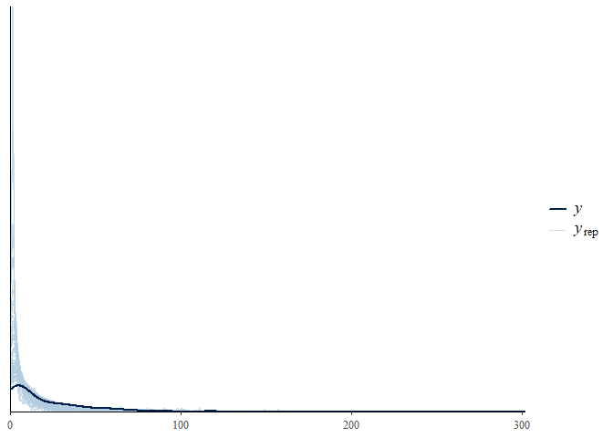

```r
pp_check(like_psych_1, ndraws = 100)
```

Psychological - minor:

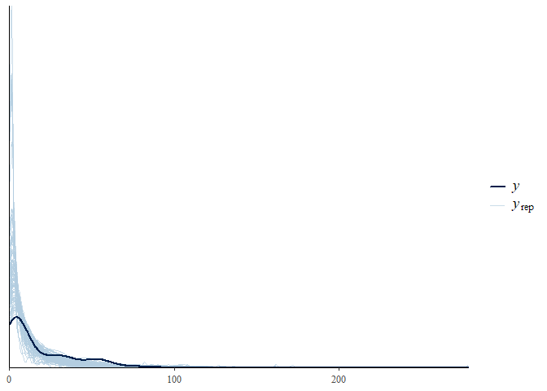

```r
pp_check(like_psych_min_1, ndraws = 100)
```

Psychological - severe:

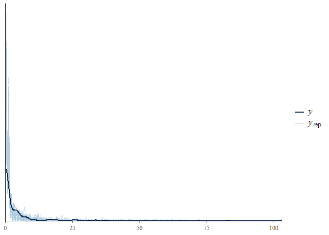

```r
pp_check(like_psych_sev_1, ndraws = 100)
```

Physical:

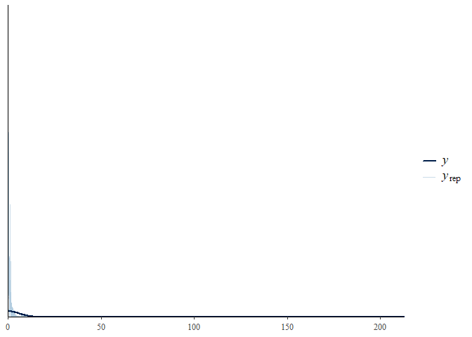

```r
pp_check(like_phys_1, ndraws = 100)
```

SGM_specific:

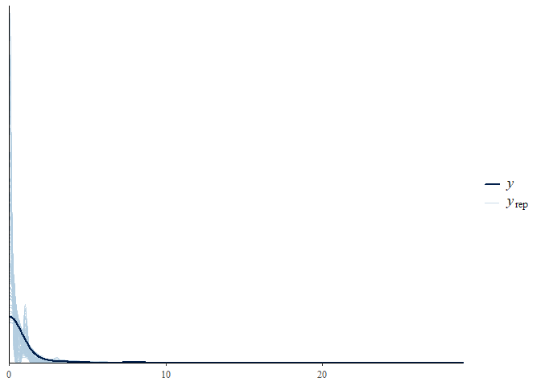

```r
pp_check(like_sgm_1, ndraws = 100)
```

Not too terrible there with any of these! Physical is the least similar, but not that the wide range is likely because of the one couple (1082) with a very large number of physical acts (213) so it’s going to show on the y-axis there.

Up to now, we’ve been ignoring the non-independence that is introduced by couple nesting. This is absolutely something we are going to have to model, so now let’s turn to how we can set some sensible priors when we account for dyad-level variation in estimated odds of being a 0 and mean/rates of IPV perpetraton frequency.

### Couple nesting

Let’s see what happens when we account for dyadic interdependence. We’ll leave the default prior on intercept variation in these models to see what that looks like.

```r
like_psych_2 <- brm(bf(CTS_psych_perp_HR ~ 0 + Intercept + (1 | CoupleID),
                     hu ~ 0 + Intercept+ (1 | CoupleID)),
                  prior = c(prior(normal(1, 0.5), class = b, coef = Intercept), # prior on mean (log scale)
                            prior(normal(-1.5, 1), class = b, coef = Intercept, dpar = hu), # prior on odds of being 0 (logit scale)
                            prior(exponential(1), class = shape) # prior on dispersion
                  ),
                  data = data,
                  family = hurdle_negbinomial(),
                  chains = 4, iter = 2000, warmup = 1000, cores = 4,
                  seed = 1234,
                  file = "fits/like_psych_2",
                  file_refit = "on_change"
                  )
like_psych_min_2 <- brm(bf(CTS_psych_perp_HR_minor ~ 0 + Intercept + (1 | CoupleID),
                     hu ~ 0 + Intercept+ (1 | CoupleID)),
                  prior = c(prior(normal(1, 0.5), class = b, coef = Intercept), # prior on mean (log scale)
                            prior(normal(-1.5, 1), class = b, coef = Intercept, dpar = hu), # prior on odds of being 0 (logit scale)
                            prior(exponential(1), class = shape) # prior on dispersion
                  ),
                  data = data,
                  family = hurdle_negbinomial(),
                  chains = 4, iter = 2000, warmup = 1000, cores = 4,
                  seed = 1234,
                  file = "fits/like_psych_min_2",
                  file_refit = "on_change"
                  )

like_psych_sev_2 <- brm(bf(CTS_psych_perp_HR_severe ~ 0 + Intercept + (1 | CoupleID),
                     hu ~ 0 + Intercept+ (1 | CoupleID)),
                  prior = c(prior(normal(1, 0.5), class = b, coef = Intercept), # prior on mean (log scale)
                            prior(normal(0, 0.5), class = b, coef = Intercept, dpar = hu), # prior on odds of being 0 (logit scale)
                            prior(exponential(1), class = shape) # prior on dispersion
                  ),
                  data = data,
                  family = hurdle_negbinomial(),
                  chains = 4, iter = 2000, warmup = 1000, cores = 4,
                  seed = 1234,
                  file = "fits/like_psych_sev_2",
                  file_refit = "on_change"
                  )
like_phys_2 <- brm(bf(CTS_phys_perp_HR ~ 0 + Intercept+ (1 | CoupleID),
                     hu ~ 0 + Intercept+ (1 | CoupleID)),
                  prior = c(prior(normal(0, 0.8), class = b, coef = Intercept), # prior on mean (log scale)
                            prior(normal(1.5, 1), class = b, coef = Intercept, dpar = hu), # prior on odds of being 0 (logit scale)
                            prior(exponential(1), class = shape) # prior on dispersion
                  ),
                 data = data,
                  family = hurdle_negbinomial(),
                  chains = 4, iter = 2000, warmup = 1000, cores = 4,
                  seed = 1234,
                  file = "fits/like_phys_2",
                  file_refit = "on_change"
                  )
like_sgm_2 <- brm(bf(CTS_sgm_perp_HR ~ 0 + Intercept + (1 | CoupleID),
                   hu ~ 0 + Intercept + (1 | CoupleID)),
                  prior = c(prior(normal(0, 0.8), class = b, coef = Intercept), # prior on mean (log scale)
                            prior(normal(1.5, 1), class = b, coef = Intercept, dpar = hu), # prior on odds of being 0 (logit scale)
                            prior(exponential(1), class = shape) # prior on dispersion
                  ),
                data = data,
                  family = hurdle_negbinomial(),
                  chains = 4, iter = 2000, warmup = 1000, cores = 4,
                  seed = 1234,
                  file = "fits/like_sgm_2",
                  file_refit = "on_change"
                  )
```

Now let’s summarize & look at the posterior predictive checks for each model. Starting with psychological:

```r
summary(like_psych_2)
```

```
##  Family: hurdle_negbinomial
##   Links: mu = log; shape = identity; hu = logit
## Formula: CTS_psych_perp_HR ~ 0 + Intercept + (1 | CoupleID)
##          hu ~ 0 + Intercept + (1 | CoupleID)
##    Data: data (Number of observations: 164)
##   Draws: 4 chains, each with iter = 2000; warmup = 1000; thin = 1;
##          total post-warmup draws = 4000
##
## Multilevel Hyperparameters:
## ~CoupleID (Number of levels: 82)
##                  Estimate Est.Error l-95% CI u-95% CI Rhat Bulk_ESS Tail_ESS
## sd(Intercept)        1.40      0.14     1.15     1.69 1.00      999     1688
## sd(hu_Intercept)     1.99      0.66     0.66     3.35 1.00     1020      813
##
## Regression Coefficients:
##              Estimate Est.Error l-95% CI u-95% CI Rhat Bulk_ESS Tail_ESS
## Intercept        2.25      0.16     1.93     2.56 1.00      592     1228
## hu_Intercept    -3.38      0.58    -4.56    -2.32 1.00     1550     1798
##
## Further Distributional Parameters:
##       Estimate Est.Error l-95% CI u-95% CI Rhat Bulk_ESS Tail_ESS
## shape     6.90      1.59     4.23    10.48 1.00     2427     3008
##
## Draws were sampled using sample(hmc). For each parameter, Bulk_ESS
## and Tail_ESS are effective sample size measures, and Rhat is the potential
## scale reduction factor on split chains (at convergence, Rhat = 1).
```

& PPC:

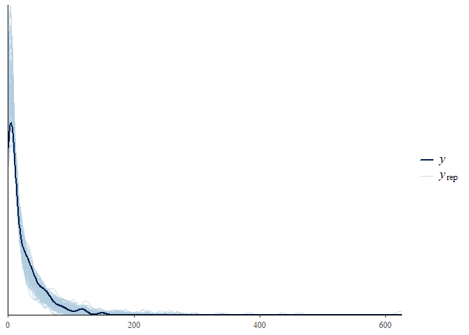

```r
pp_check(like_psych_2, ndraws = 100)
```

Psychological minor:

```r
summary(like_psych_min_2)
```

```
##  Family: hurdle_negbinomial
##   Links: mu = log; shape = identity; hu = logit
## Formula: CTS_psych_perp_HR_minor ~ 0 + Intercept + (1 | CoupleID)
##          hu ~ 0 + Intercept + (1 | CoupleID)
##    Data: data (Number of observations: 168)
##   Draws: 4 chains, each with iter = 2000; warmup = 1000; thin = 1;
##          total post-warmup draws = 4000
##
## Multilevel Hyperparameters:
## ~CoupleID (Number of levels: 84)
##                  Estimate Est.Error l-95% CI u-95% CI Rhat Bulk_ESS Tail_ESS
## sd(Intercept)        1.32      0.13     1.08     1.60 1.00      749     1458
## sd(hu_Intercept)     1.82      0.65     0.58     3.17 1.00     1342     1364
##
## Regression Coefficients:
##              Estimate Est.Error l-95% CI u-95% CI Rhat Bulk_ESS Tail_ESS
## Intercept        2.13      0.15     1.83     2.44 1.00      561     1204
## hu_Intercept    -3.04      0.55    -4.18    -2.06 1.00     1840     2683
##
## Further Distributional Parameters:
##       Estimate Est.Error l-95% CI u-95% CI Rhat Bulk_ESS Tail_ESS
## shape     7.73      1.82     4.68    11.79 1.00     2448     2825
##
## Draws were sampled using sample(hmc). For each parameter, Bulk_ESS
## and Tail_ESS are effective sample size measures, and Rhat is the potential
## scale reduction factor on split chains (at convergence, Rhat = 1).
```

& PPC:

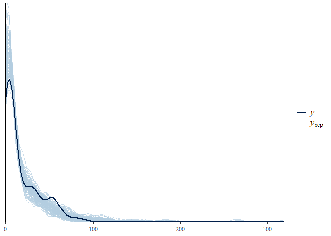

```r
pp_check(like_psych_min_2, ndraws = 100)
```

Psychological severe:

```r
summary(like_psych_sev_2)
```

```
##  Family: hurdle_negbinomial
##   Links: mu = log; shape = identity; hu = logit
## Formula: CTS_psych_perp_HR_severe ~ 0 + Intercept + (1 | CoupleID)
##          hu ~ 0 + Intercept + (1 | CoupleID)
##    Data: data (Number of observations: 164)
##   Draws: 4 chains, each with iter = 2000; warmup = 1000; thin = 1;
##          total post-warmup draws = 4000
##
## Multilevel Hyperparameters:
## ~CoupleID (Number of levels: 82)
##                  Estimate Est.Error l-95% CI u-95% CI Rhat Bulk_ESS Tail_ESS
## sd(Intercept)        1.29      0.23     0.90     1.82 1.00     1267     2013
## sd(hu_Intercept)     4.28      1.19     2.50     7.03 1.00     1689     2483
##
## Regression Coefficients:
##              Estimate Est.Error l-95% CI u-95% CI Rhat Bulk_ESS Tail_ESS
## Intercept        1.31      0.23     0.84     1.73 1.00     1469     2306
## hu_Intercept     0.23      0.37    -0.49     0.97 1.00     2795     2823
##
## Further Distributional Parameters:
##       Estimate Est.Error l-95% CI u-95% CI Rhat Bulk_ESS Tail_ESS
## shape     2.60      0.99     1.02     4.86 1.00     1788     1797
##
## Draws were sampled using sample(hmc). For each parameter, Bulk_ESS
## and Tail_ESS are effective sample size measures, and Rhat is the potential
## scale reduction factor on split chains (at convergence, Rhat = 1).
```

& PPC:

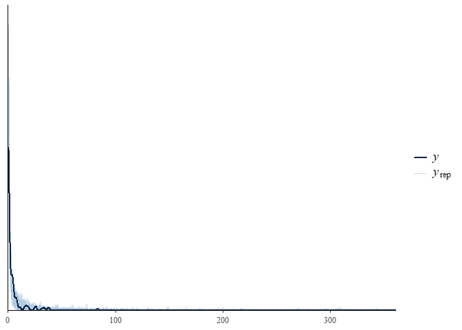

```r
pp_check(like_psych_sev_2, ndraws = 100)
```

Physical:

```r
summary(like_phys_2)
```

```
##  Family: hurdle_negbinomial
##   Links: mu = log; shape = identity; hu = logit
## Formula: CTS_phys_perp_HR ~ 0 + Intercept + (1 | CoupleID)
##          hu ~ 0 + Intercept + (1 | CoupleID)
##    Data: data (Number of observations: 164)
##   Draws: 4 chains, each with iter = 2000; warmup = 1000; thin = 1;
##          total post-warmup draws = 4000
##
## Multilevel Hyperparameters:
## ~CoupleID (Number of levels: 82)
##                  Estimate Est.Error l-95% CI u-95% CI Rhat Bulk_ESS Tail_ESS
## sd(Intercept)        2.61      0.75     1.47     4.34 1.00     2340     2923
## sd(hu_Intercept)     3.56      0.89     2.10     5.52 1.00     1980     2534
##
## Regression Coefficients:
##              Estimate Est.Error l-95% CI u-95% CI Rhat Bulk_ESS Tail_ESS
## Intercept        0.09      0.58    -1.10     1.18 1.00     3902     3134
## hu_Intercept     3.46      0.61     2.36     4.70 1.00     3691     2921
##
## Further Distributional Parameters:
##       Estimate Est.Error l-95% CI u-95% CI Rhat Bulk_ESS Tail_ESS
## shape     1.60      1.10     0.14     4.26 1.00     1836     2087
##
## Draws were sampled using sample(hmc). For each parameter, Bulk_ESS
## and Tail_ESS are effective sample size measures, and Rhat is the potential
## scale reduction factor on split chains (at convergence, Rhat = 1).
```

& PPC:

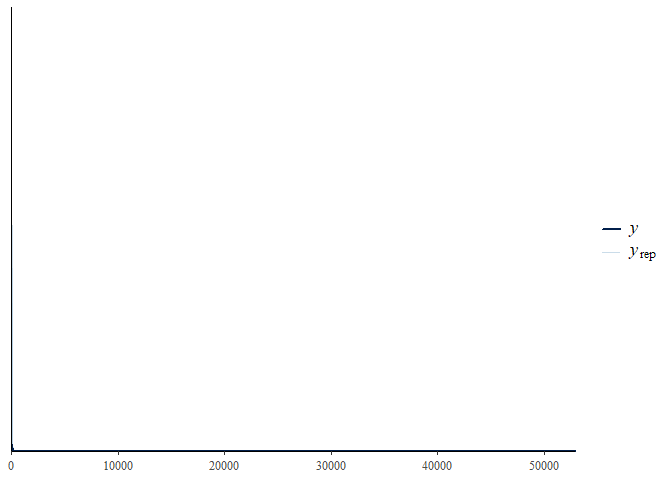

```r
pp_check(like_phys_2, ndraws = 100)
```

SGM-specific:

```r
summary(like_sgm_2, ndraws = 100)
```

```
##  Family: hurdle_negbinomial
##   Links: mu = log; shape = identity; hu = logit
## Formula: CTS_sgm_perp_HR ~ 0 + Intercept + (1 | CoupleID)
##          hu ~ 0 + Intercept + (1 | CoupleID)
##    Data: data (Number of observations: 164)
##   Draws: 4 chains, each with iter = 2000; warmup = 1000; thin = 1;
##          total post-warmup draws = 4000
##
## Multilevel Hyperparameters:
## ~CoupleID (Number of levels: 82)
##                  Estimate Est.Error l-95% CI u-95% CI Rhat Bulk_ESS Tail_ESS
## sd(Intercept)        1.08      0.52     0.14     2.27 1.00      974      979
## sd(hu_Intercept)     2.28      0.68     1.07     3.75 1.00     1458     2072
##
## Regression Coefficients:
##              Estimate Est.Error l-95% CI u-95% CI Rhat Bulk_ESS Tail_ESS
## Intercept        0.67      0.47    -0.40     1.46 1.00     3162     2276
## hu_Intercept     2.95      0.55     2.00     4.16 1.00     2466     2805
##
## Further Distributional Parameters:
##       Estimate Est.Error l-95% CI u-95% CI Rhat Bulk_ESS Tail_ESS
## shape     1.47      1.28     0.09     4.61 1.00     1204     1775
##
## Draws were sampled using sample(hmc). For each parameter, Bulk_ESS
## and Tail_ESS are effective sample size measures, and Rhat is the potential
## scale reduction factor on split chains (at convergence, Rhat = 1).
```

& PPC:

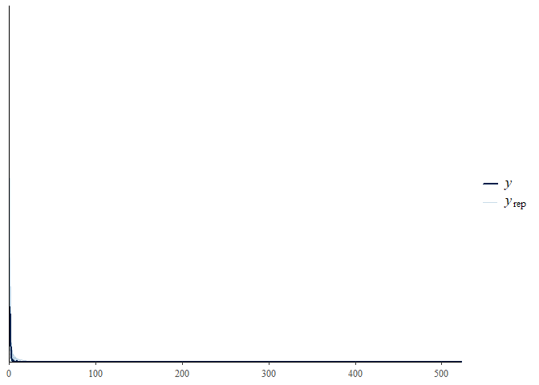

```r
pp_check(like_sgm_2, ndraws = 100)
```